# Lecture 3 R Practice

Sangjin Lee

2024년 4월 1일

```r
library(ggplot2)
library(dplyr)
# install.packages("agricolae")
library(agricolae)
library(DescTools)
```

### (1) Permuational F-test

#### $F_i(x) = F(x-\mu_i), \ i=1, ..., K$

#### $H_0: F_1(x) = ... = F_K(x)$

#### Example: 주말 오후 1-3시에 서울 잠실 일대 공유 전동킥보드 세 브랜드(킥고잉, 라임, 고고씽)의 이용 시간을 조사하였다.

```r
kick <- read.csv("kickboard.csv")
head(kick)
```

```
##   time brand
## 1   10    KG
## 2   10    KG
## 3   10    KG
## 4   10    KG
## 5   10    KG
## 6   11    KG
```

```r
group_by(kick, brand) %>%
  summarise(count=n(), mean=mean(time), sd=sd(time))
```

```
## # A tibble: 3 × 4
##   brand count  mean    sd
##   <chr> <int> <dbl> <dbl>
## 1 GG       22  26.2 12.5
## 2 KG       32  20.1  8.13
## 3 Lime    101  25.2 15.8
```

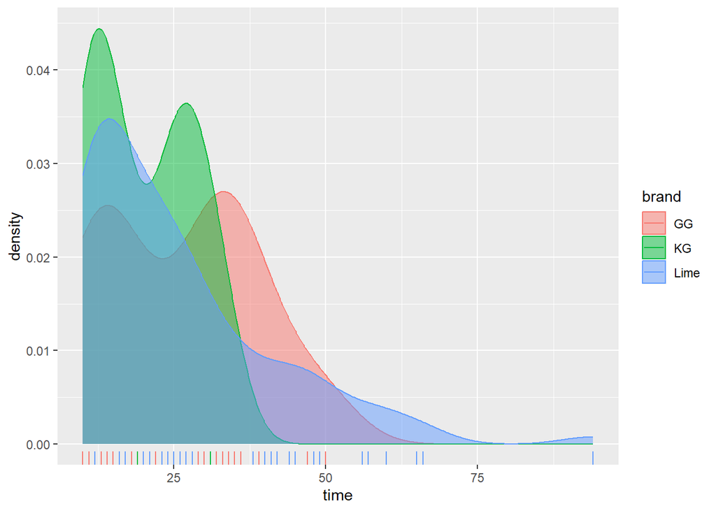

```r
ggplot(kick, aes(x=time, color=brand, fill=brand)) +
  geom_density(alpha=0.5) + geom_rug()
```

```r
summary(aov(time ~ brand, data=kick))
```

```
##              Df Sum Sq Mean Sq F value Pr(>F)
## brand         2    739     370    1.86   0.16
## Residuals   152  30287     199
```

```r
N <- nrow(kick); K <- 3

group.length <- aggregate(kick$time, by=list(kick$brand), length)[,2]
group.mean <- aggregate(kick$time, by=list(kick$brand), mean)[,2]

SSTotal <- var(kick$time) * (length(kick$time)-1)
SST <- sum(group.length * (group.mean - mean(kick$time))^2)
SSE <- SSTotal - SST

F.obs <- (SST/(K-1))/(SSE/(N-K)); F.obs
```

```
## [1] 1.8555
```

```r
R = 999 # number of permutations
F.perm <- vector(length=R)
for (r in 1:R) {
  perm <- sample(1:N, replace=FALSE)
  group.length <- aggregate(kick$time, by=list(kick$brand[perm]), length)[,2]
  group.mean <- aggregate(kick$time, by=list(kick$brand[perm]), mean)[,2]

  SSTotal <- var(kick$time) * (length(kick$time)-1)
  SST <- sum(group.length * (group.mean - mean(kick$time))^2)
  SSE <- SSTotal - SST
  F.perm[r] <- (SST/(K-1))/(SSE/(N-K))
}

p.value <- (sum(F.perm>=F.obs)+1)/(R+1); p.value
```

```
## [1] 0.159
```

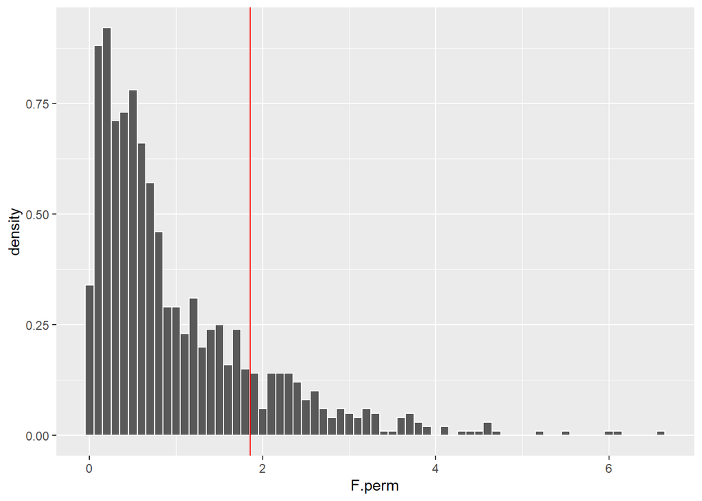

```r
data.frame(F.perm=F.perm) %>% ggplot(aes(x=F.perm)) +
  geom_histogram(aes(y=..density..), binwidth=0.1, color="white") +
  geom_vline(xintercept=F.obs, color='red')
```

### (2) Kruskal-Wallis test: without ties

#### $F_i = F(x-\mu_i), \ i=1, …, K$

#### $H_0: F_1(x) = … = F_K(x)$

#### Example: 떡갈나무 16그루에 대해 연간 밑둥 직경의 증가량을 측정하였다. 각 나무는 위치한 부지의 경사도에 따라 분류되었다. (1: 경사 급함 ~ 5: 경사 없음)

```r
tree <- read.csv("tree.csv")
head(tree)
```

```
##   increment slope
## 1      1.91     1
## 2      1.53     1
## 3      2.08     1
## 4      1.71     1
## 5      2.44     2
## 6      2.45     3
```

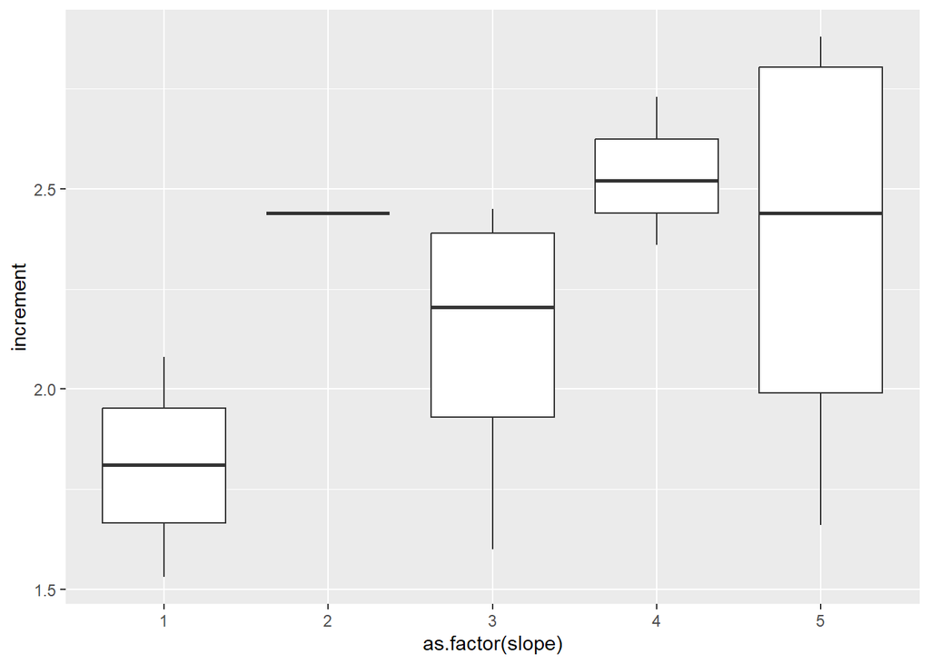

```r
ggplot(tree, aes(x=as.factor(slope), y=increment)) + geom_boxplot()
```

```r
kruskal.test(increment ~ slope, data=tree)
```

```
##
##  Kruskal-Wallis rank sum test
##
## data:  increment by slope
## Kruskal-Wallis chi-squared = 5.97, df = 4, p-value = 0.2
```

```r
tree.rank <- tree %>% mutate(rank=rank(increment))
head(tree.rank)
```

```
##   increment slope rank
## 1      1.91     1    5
## 2      1.53     1    1
## 3      2.08     1    7
## 4      1.71     1    4
## 5      2.44     2   11
## 6      2.45     3   12
```

```r
group.length <- aggregate(rank ~ slope, data=tree.rank, length)[,2]
group.rank.mean <- aggregate(rank ~ slope, data=tree.rank, mean)[,2]
```

```r
N <- sum(group.length); K <- length(group.length)
KW.obs <- ( 12/(N*(N+1))) * sum( group.length * (group.rank.mean - (N+1)/2)^2 )
KW.obs
```

```
## [1] 5.9669
```

```r
p.value <- pchisq(KW.obs, df=K-1, lower.tail=F)
p.value
```

```
## [1] 0.20163
```

### (3) Jonckheere-Terpstra Test: ordered alternative

#### $H_a: F_i(x) \geq F_j(x)$ for $i < j$

```r
tree$slope <- factor(tree$slope, ordered=TRUE)
# exact test
DescTools::JonckheereTerpstraTest(increment ~ slope, data=tree, alternative="increasing")
```

```
##
##  Jonckheere-Terpstra test
##
## data:  increment by slope
## JT = 73, p-value = 0.015
## alternative hypothesis: increasing
```

### (4) Multiple testing: controlling FWER

#### $X_{l, 1}, …, X_{1, 100} \sim N(\mu_l,1), \ l=1, ..., 20$

#### $H_{0l}: \mu_{l}=0, \ l=, …, 20$

#### The following simulations shows that setting $\alpha=0.05$ for each test leads to undesired results.

```r
L=20 # number of tests
n=100 # size of samples
R=1000
err.vec <- vector(length=R)
for (r in 1:R) {
  fam.err <- FALSE
  x=matrix(rnorm(n*L), nrow=n)
  for (i in 1:L) {
    if (t.test(x[,i], mu=0)$p.value < 0.05) {
      fam.err <- TRUE
      break
    }
  }
  err.vec[r] <- fam.err
}

(fam.err.rate <- sum(err.vec)/R)
```

```
## [1] 0.641
```

#### Given that $H_{0l}, \ l=1, ..., 20$ being all true,

#### FWER = Pr(at least one type 1 error in the family)

#### = 1 - Pr(no type 1 error in the family)

#### = $1- (1 - 0.05)^{20}$

```r
1 - (1-0.05)^20
```

```
## [1] 0.64151
```

#### Need to use a smaller significance level $\alpha\prime$ for each pairwise test!

### (5) Multiple comparisons: Bonferroni adjustment

#### Example: Percentages of clay in soil samples from four locations. (Populations are normally distributed with equal variances.)

```r
clay <- read.csv("clay.csv")
head(clay)
```

```
##    pct location
## 1 26.5        1
## 2 15.0        1
## 3 18.2        1
## 4 19.5        1
## 5 23.1        1
## 6 17.3        1
```

```r
group_by(clay, location) %>%
  summarise(count=n(), mean=mean(pct), sd=sd(pct))
```

```
## # A tibble: 4 × 4
##   location count  mean    sd
##      <int> <int> <dbl> <dbl>
## 1        1     6  19.9  4.19
## 2        2     6  19.8  6.35
## 3        3     6  25.4  5.89
## 4        4     6  30.3  4.33
```

```r
summary(aov(pct ~ as.factor(location), data=clay))
```

```
##                     Df Sum Sq Mean Sq F value Pr(>F)
## as.factor(location)  3    452   150.8    5.42 0.0068 **
## Residuals           20    556    27.8
## ---
## Signif. codes:  0 '***' 0.001 '**' 0.01 '*' 0.05 '.' 0.1 ' ' 1
```

#### Bonferroni adjustment is to do each of the $K(K-1)/2=6$ comparisons at level of significance $\alpha\prime = \alpha/6$.

```r
pct.all <- matrix( c(clay$pct[clay$location==1],
                     clay$pct[clay$location==2],
                     clay$pct[clay$location==3],
                     clay$pct[clay$location==4]),
                   byrow=FALSE, ncol=4 )

pvals <- matrix(, nrow=4, ncol=4)
for (i in 1:4) {
  j <- i+1
  while(j<=4) {
    pvals[i,j] <- t.test(pct.all[,i], pct.all[,j], var.equal=TRUE)$p.value
    j <- j+1}
}

pvals # raw p-values
```

```
##      [,1]    [,2]     [,3]      [,4]
## [1,]   NA 0.97911 0.096298 0.0017560
## [2,]   NA      NA 0.150854 0.0075116
## [3,]   NA      NA       NA 0.1270221
## [4,]   NA      NA       NA        NA
```

```r
pvals[is.na(pvals)==FALSE] <- p.adjust(pvals[is.na(pvals)==FALSE], method="bonferroni")
```

```r
pvals # Bonferroni-adjusted p-values
```

```
##      [,1] [,2]    [,3]     [,4]
## [1,]   NA    1 0.57779 0.010536
## [2,]   NA   NA 0.90512 0.045070
## [3,]   NA   NA      NA 0.762133
## [4,]   NA   NA      NA       NA
```

```r
t.test(clay$pct[clay$location==2], clay$pct[clay$location==4], var.equal=TRUE)$p.value*6
```

```
## [1] 0.04507
```

```r
(bonf.critical.value <- qt(0.025/6, df=2*6-2))
```

```
## [1] -3.2768
```

### (6) Multiple comparisons: Fisher’s protected LSD

#### Fisher’s LSD procedure is to declare means for treatments $i$ and $j$ to be different if

#### $|\bar{X}_i - \bar{X}_j| \geq t(\alpha/2, df=N-K) \sqrt{MSE(2/6)}$

```r
N <- nrow(clay); K <-4
clay$location <- as.factor(clay$location)
model <- aov(pct ~ location, data=clay)

MSE <- deviance(model)/df.residual(model)

(lsd.critical.value <- qt(0.025, df=N-K) * sqrt(MSE*(2/6)))
```

```
## [1] -6.3508
```

```r
(agricolae::LSD.test(model, "location", p.adj="none"))
```

```
## $statistics
##   MSerror Df   Mean     CV t.value    LSD
##    27.808 20 23.863 22.099   2.086 6.3508
##
## $parameters
##         test p.ajusted   name.t ntr alpha
##   Fisher-LSD      none location   4  0.05
##
## $means
##      pct    std r     se    LCL    UCL  Min  Max    Q25   Q50    Q75
## 1 19.933 4.1860 6 2.1528 15.443 24.424 15.0 26.5 17.525 18.85 22.200
## 2 19.850 6.3463 6 2.1528 15.359 24.341 14.1 30.2 15.975 16.95 23.175
## 3 25.350 5.8930 6 2.1528 20.859 29.841 19.2 35.0 21.450 23.80 28.175
## 4 30.317 4.3250 6 2.1528 25.826 34.807 26.3 37.3 27.025 29.05 32.650
##
## $comparison
## NULL
##
## $groups
##      pct groups
## 4 30.317      a
## 3 25.350     ab
## 1 19.933      b
## 2 19.850      b
##
## attr(,"class")
## [1] "group"
```

### (7) Multiple comprisons: Tukey’s HSD

#### Tukey’s HSD procedure considers a statistic that measures the largest difference between sample means:

#### $Q=\max_{ij} \{ \frac{\sqrt{n}|\bar{X}_i-\bar{X}_j|}{\sqrt{MSE}} \} = \frac{\sqrt{n} (\max_{i}\bar{X}_i- \min_{i} \bar{X}_i)}{\sqrt{MSE}}.$

#### The procedure declares means for treatment $i$ and $j$ to be different if

#### $|\bar{X}_i-\bar{X}_j|/\sqrt{MSE/n} \geq q(\alpha, K, df=N-k)$

#### where $q(\alpha, K, df=N-k)$ is the upper-tail $100\alpha$% point of the distribution of $Q$.

```r
(out <- TukeyHSD(model, "location", ordered=FALSE))
```

```
##   Tukey multiple comparisons of means
##     95% family-wise confidence level
##
## Fit: aov(formula = pct ~ location, data = clay)
##
## $location
##          diff     lwr     upr   p adj
## 2-1 -0.083333 -8.6048  8.4381 0.99999
## 3-1  5.416667 -3.1048 13.9381 0.31194
## 4-1 10.383333  1.8619 18.9048 0.01357
## 3-2  5.500000 -3.0215 14.0215 0.29951
## 4-2 10.466667  1.9452 18.9881 0.01277
## 4-3  4.966667 -3.5548 13.4881 0.38453
```

```r
Tij.obs <- abs(out$location[,1]); Tij.obs
```

```
##       2-1       3-1       4-1       3-2       4-2       4-3
##  0.083333  5.416667 10.383333  5.500000 10.466667  4.966667
```

```r
R = 2000
Q.perm <- vector(length=R)
for (r in 1:R) {
  clay.perm <- data.frame(pct = clay$pct, location=clay$location[sample(1:N, replace=FALSE)])
  model <- aov(pct ~ location, data=clay.perm)
  MSE <- deviance(model)/df.residual(model)
  group.mean <- aggregate(pct ~ location, data=clay.perm, mean)[,2]
  Tij <- abs(outer(group.mean, group.mean, "-"))/ sqrt(MSE/6)
  Q.perm[r] <- max(Tij)
}
```

```r
( p.values <- unlist(purrr::map(Tij.obs, function(x) {sum(Q.perm>=x)/R})) )
```

```
##    2-1    3-1    4-1    3-2    4-2    4-3
## 1.0000 0.0095 0.0000 0.0090 0.0000 0.0140
```

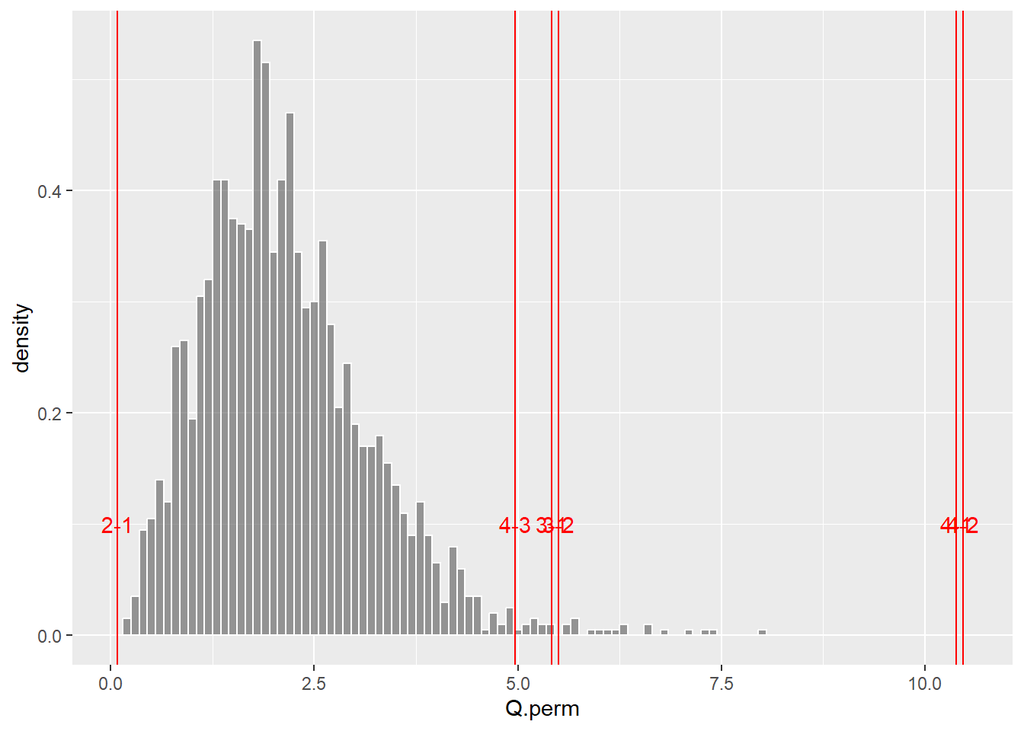

```r
data.frame(Q.perm=Q.perm) %>% ggplot(aes(Q.perm)) +
  geom_histogram(aes(y=..density..), binwidth=0.1, color="white", alpha=0.6) +
  geom_vline(xintercept=Tij.obs, color="red") +
  geom_text(data=data.frame(x=Tij.obs, label=names(Tij.obs)),
            aes(x=x, y=0.1, label=label), color="red")
```